# De Do Do Do, De Di i Di - Panel Data Methods

Data Analytics for Finance

Caspar David Peter

peter@rsm.nl

Rotterdam School of Management, Accounting Department

# Panel Data Methods

## Before We Start…

### Assignment Release and Submission Schedule

| Assignment | Release | Deadline |
| --- | --- | --- |
| A1 | 11.02.2026 | 25.02.2026 |
| A2 | 11.02.2026 | 25.02.2026 |
| A3 | 18.02.2026 | 04.03.2026 |
| A4 | **25.02.2026** | 11.03.2026 |
| A5 | 04.03.2026 | TBA |
| A6 | 11.03.2026 | TBA |

**Important Note on Assignment Deadlines**

Deadlines for A5-A6 will be announced in the coming weeks. Please stay tuned for updates and **check Canvas regularly** if you do not attend lectures.

## Overview

### Recap of previous lecture

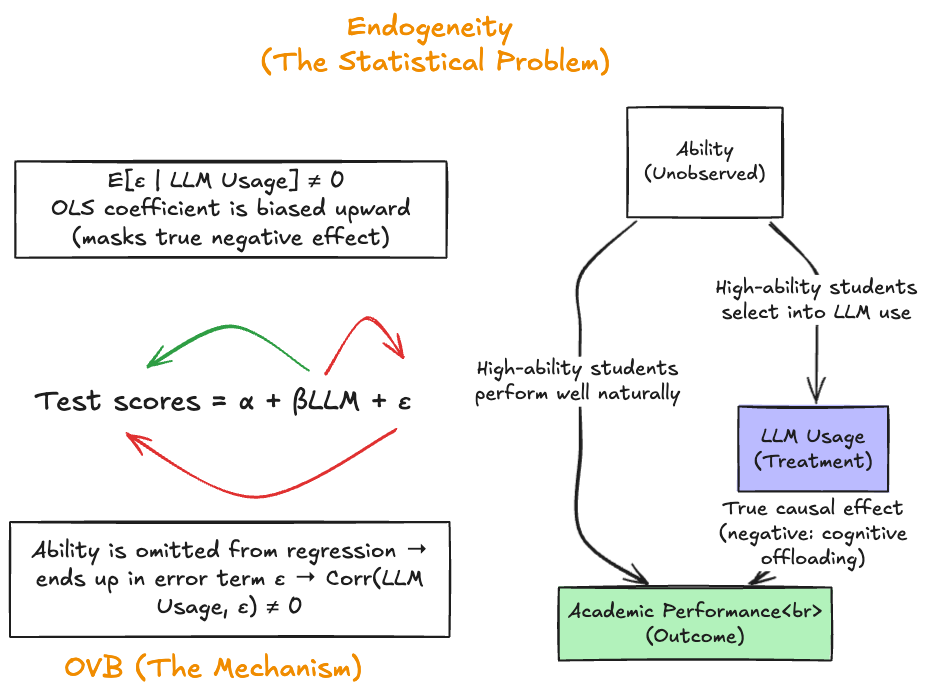

## Overview

### Today’s learning objectives

- What are good and bad controls in regression analysis?
- Understand the Difference-in-Differences (DiD) framework for causal inference using panel data
- Learn how to implement DiD design, including fixed effects
- Recognize the importance of appropriate standard error adjustments in DiD analyses
- Explore advanced DiD topics such as staggered adoption and recent methodological developments

# What to do if random assignment is not possible?

We did not answer this question in the previous lecture!

## What to do if random assignment is not possible?

### Building the OLS model

#### From Huntington-Klein (2022) chapter 13

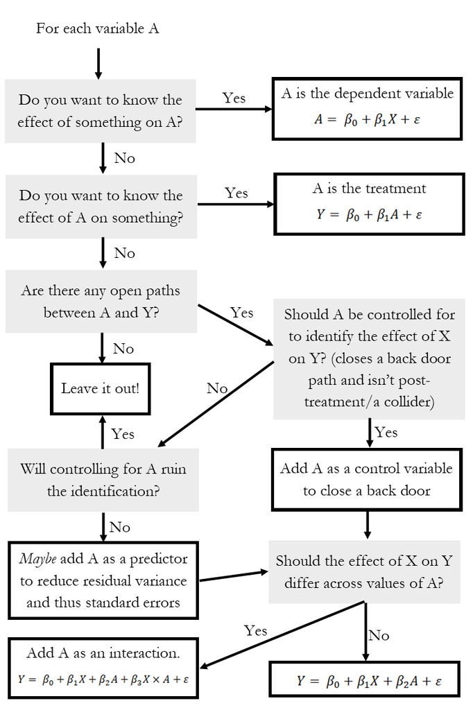

#### Let’s build the OLS model for DiLLMa

- Outcome variable: `exam_score`
- Treatment variable: `treated` (1 if student uses LLM, 0 otherwise)

## What to do if random assignment is not possible?

### Building the OLS model

#### From Huntington-Klein (2022) chapter 13

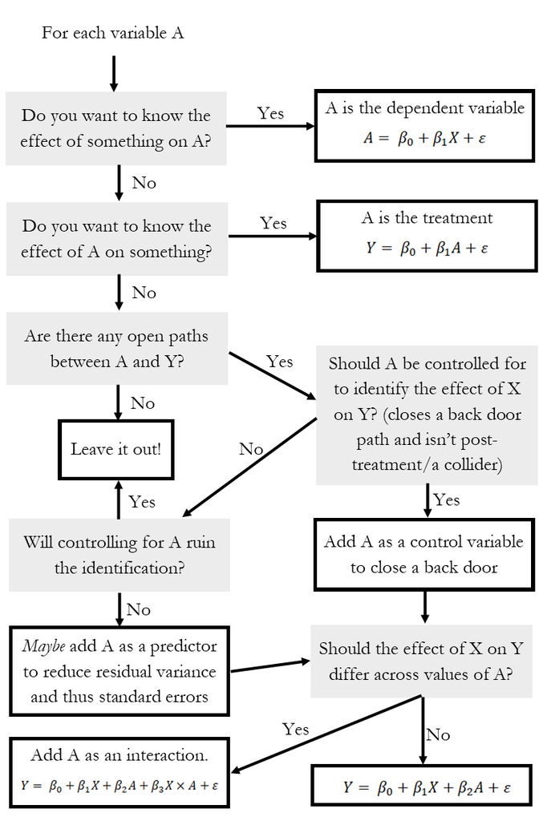

#### Let’s build the OLS model for DiLLMa

# Control Variables in Regression Analysis

## Control Variables in Regression Analysis

### Good vs. Bad controls

#### Good controls

- Variables that are **not caused by the treatment** — they can be correlated with both treatment and outcome
- Closing a “backdoor path” (confounder) reduces omitted variable bias (ability is a good control, but unobservable)
- Pure outcome predictors (uncorrelated with treatment) improve precision without biasing estimates

#### Bad controls

- Variables that lie on the causal path from treatment to outcome (mediators)
- Variables that are *caused by* both treatment and outcome (colliders)
- Adding every available variable is *not* a safe strategy

## Control Variables in Regression Analysis

### Good controls - Examples

#### Confounder - “Common cause”

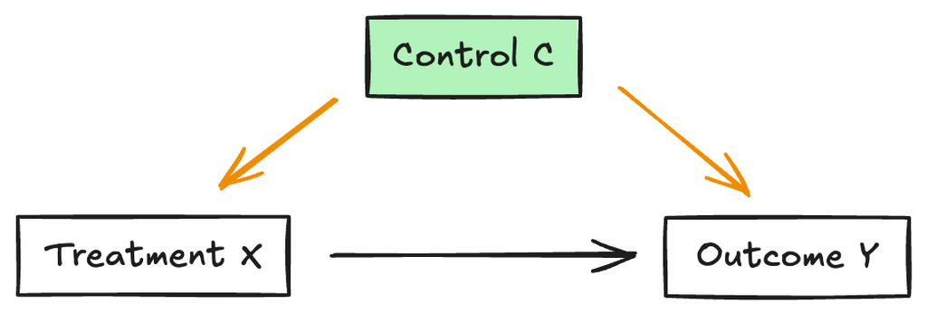

#### Lecture 3 example: Student ability

- Controlling for ability helps isolate the causal effect of LLM use on scores by blocking this backdoor path: LLM use ← ability → exam score
- Other good controls could include age, gender, etc. — variables that are correlated with both LLM use and exam scores but are not caused by LLM use

For more details on causal diagrams check Huntington-Klein (2022) chapters 6-9 and bad controls Cinelli et al. (2024)!

## Control Variables in Regression Analysis

### Bad controls — Collider

#### Structure: X → Z ← Y

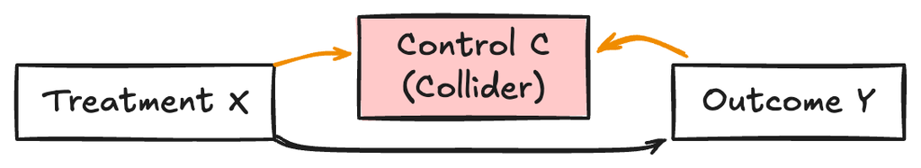

- Z is *caused by* both X and Y — two arrows point **into** Z
- Conditioning on Z **opens** a spurious path between X and Y, creating a phantom association that does not exist in the full population

#### Example: Office hour attendance

- Some students need to check “hallucinated” or complicated LLM responses during preparation via office hour attendance (X → Z)
- Other students attend office hours because they are struggling with the material (Y → Z) and expect a lower score

## Control Variables in Regression Analysis

### Summary

- Good controls help isolate the causal effect by blocking non-causal paths (confounders)
- Bad controls can bias estimates by blocking causal paths (mediators) or opening spurious paths (colliders)

> “To fix a Confounder, you MUST include it. To avoid a Collider, you MUST exclude it.”

**Takeaway: Be deliberate about controls**

DiD with two-way fixed effects largely sidesteps the confounder problem by absorbing time-invariant differences between units. But **mediators remain a live concern** — if you control for a variable that lies on the causal path from your treatment to the outcome, you will underestimate the treatment effect.

# Difference-in-Differences (DiD)

## Difference-in-Differences (DiD)

### Key concepts

**What is Difference‑in‑Differences (DID)?**

Difference‑in‑Differences (DID) is a quasi‑experimental method that exploits **within‑group** variation over time and **cross‑group** variation to identify a **causal effect** when **random assignment is infeasible**.

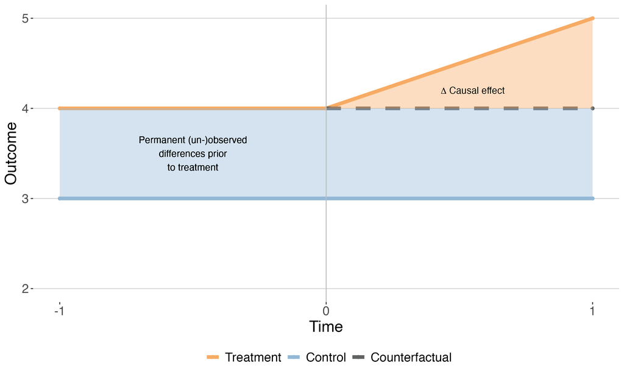

**Parallel Trends Assumption**

DiD only recovers the causal effect if the **“parallel trends assumption”** holds!

## Difference-in-Differences (DiD)

### Why Differences — Isn’t one difference enough?

#### Before vs After (time variation)

##### What is it?

Compare outcomes before and after treatment implementation, e.g. pre- and post-policy change

##### Why not enough for causal inference?

All variation in Treatment is explained by Time!

#### Treated vs Control (group variation)

##### What is it?

Compare outcomes between treated and control groups, e.g. those affected by a policy change vs those not affected

##### Why not enough for causal inference?

Differences between Treated and Control groups may be driven by **time-invariant** confounders, e.g. ability, demographics, location, etc.

Combining both allows us to isolate the **causal impact of the treatment** a.k.a. *average treatment effect on the treated (ATT)*

## Difference-in-Differences (DiD)

### DiLLMa - Setting continued

- We observe students’ exam scores before and after LLMs were introduced <sup>1</sup>
- Some courses allowed LLM use (treatment), others banned it (control)
- **Goal**: Estimate the causal effect of allowing LLM use on exam scores

#### In short

Compare grade changes in **allowed vs. banned** courses, **before and after** LLMs became available

> DiD isolates the treated group’s response, *conditional on the assumption that the untreated group’s changes represent the non-treatment counterfactual for the treated group*
[^1]: It is worth noting that the underlying data is a **panel dataset** with multiple observations per student.

## Difference-in-Differences (DiD)

### Canonical DiD model - The two-by-two design

#### The two-by-two set-up

|  | (1) After | (2) Before | (1) - (2) |
| --- | --- | --- | --- |
| (a) Treatment | Y$_{treated,\ after}$ | Y$_{treated,\ before}$ | $\Delta_{treated}$ |
| (b) Control | Y$_{control,\ after}$ | Y$_{control,\ before}$ | $\Delta_{control}$ |
| (a) - (b) | $\Delta_{after}$ | $\Delta_{before}$ | DiD |

#### A typical DiD regression looks like this

$$Y = \beta_0 + \beta_1 Treated + \beta_2 After + \beta_3 Treated \times After + \epsilon$$

- The difference-in-differences regression gives you the same estimate as if you took differences in the group averages
- It takes also care of any unobserved **constant differences between subjects** and **time trends**!

## Difference-in-Differences (DiD)

### Canonical DiD model - The two-by-two design

#### The two-by-two set-up

|  | (1) After | (2) Before | (1) - (2) |
| --- | --- | --- | --- |
| (a) Treatment | $\beta_0 + \beta_1+\beta_2+\beta_3$ | $\beta_0 + \beta_1$ | $\beta_2+\beta_3$ |
| (b) Control | $\beta_0 + \beta_2$ | $\beta_0$ | $\beta_2$ |
| (a) - (b) | $\beta_1+\beta_3$ | $\beta_1$ | $\beta_3$ |

#### A typical DiD regression looks like this

$$Y = \beta_0 + \beta_1 Treated + \beta_2 After + \beta_3 Treated \times After + \epsilon$$

- The difference-in-differences regression gives you the same estimate as if you took differences in the group averages
- It takes also care of any unobserved **constant differences between subjects** and **time trends**!

## Difference-in-Differences (DiD)

### Canonical DiD model - The two-by-two design

#### Example data summary

- Same variables as in previous lecture, but now panel data with multiple observations per student
- **Treatment assigned** at the **course level** (some instructors allow LLM use, others ban it)
- Data contains two periods: pre-LLM (before) and post-LLM (after), each consisting of two exam scores per student
- The unit of analysis is the student-time level
- The key variables are:
  - `treated`: Indicator for whether the course allows LLM use (1 = yes, 0 = no)
  - `after`: Indicator for whether the observation is from the post-LLM period (1 = after, 0 = before)
  - `exam_score`: The student’s exam score

## Difference-in-Differences (DiD)

### Canonical DiD model - The two-by-two design

#### Comparing means

|  | After | Before | Difference |
| --- | --- | --- | --- |
| Treated group | 6.57 | 7.12 | -0.55 |
| Control group | 7.42 | 7.22 | 0.20 |
| Difference | -0.85 | -0.10 | -0.75 |

#### Estimation

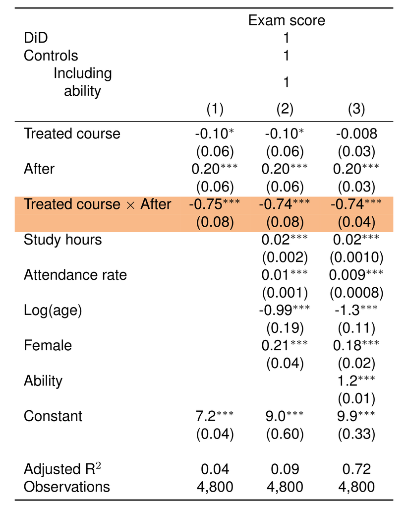

## Difference-in-Differences (DiD)

### Two-way fixed effects (TWFE)

**Canonical:** $Y = \underbrace{\beta_0 + \beta_1 Treated}_{\alpha_i} + \underbrace{\beta_2 After}_{\alpha_t} + \beta_3 Treated \times After + \epsilon$

**TWFE:** $Y = \alpha_i + \alpha_t + \beta_{DiD}\ Treated \times After + \epsilon$

##### What is absorbed by fixed effects?

- $\beta_0$ is absorbed into the individual fixed effects $\alpha_i$ — every unit gets its own intercept
- $\beta_1$ disappears - time-invariant differences are absorbed by individual fixed effects
- $\beta_2$ disappears - time fixed effects capture common shocks over time

##### Why use fixed effects?

- Controls for unobserved heterogeneity across individuals and over time
- Focuses on within-individual variation to identify treatment effects
- More robust to **omitted variable bias** from **time-invariant confounders**

## Difference-in-Differences (DiD)

### Two-way fixed effects

#### Estimation with fixed effects

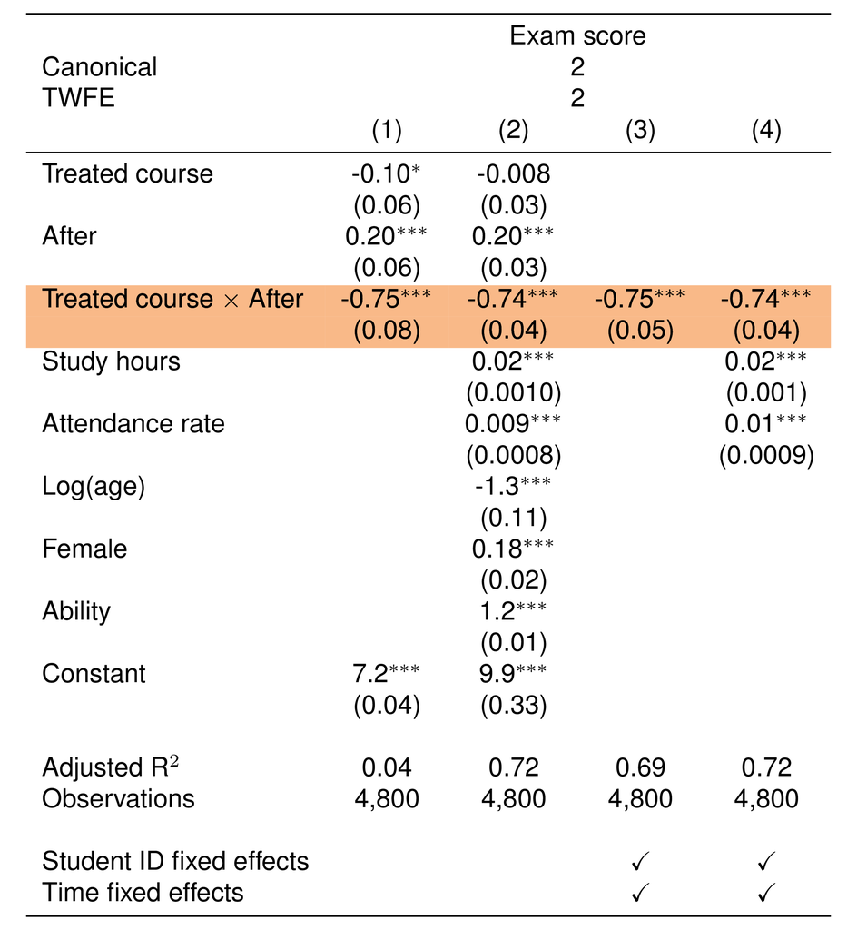

#### What changes with fixed effects?

- The DiD estimate remains similar, indicating robustness to fixed effects
- Controls for unobserved individual heterogeneity and time effects
- Time-invariant confounders are addressed — `ability` drops out automatically because it is constant per student and is fully absorbed by the student fixed effect
- Parallel Trends
- But what about standard errors?

For an excellent deep-dive into fixed effects, see e.g. Breuer and DeHaan (2024) or Verbeek (2021)

## Difference-in-Differences (DiD)

### Two-way fixed effects (TWFE)

#### Under the Hood: What do fixed effects actually do?

- Any time-invariant characteristic that cannot be observed in the data $=$ fixed effect
- Fixed effects only use **within-unit variation over time** — all cross-sectional differences between units are swept away. This is why time-invariant variables like `ability` and `female` drop out automatically: once you subtract each student’s own mean, a constant value cancels out completely
- Use with caution! Do not *fix effect away* what you want to measure (e.g. do not use firm FE if your research question is about cross-sectional variation across firms)

> Fixed effects solve endogeneity from **time-invariant** omitted variables. They do **not** solve endogeneity from **time-varying** confounders — if something unobserved changes over time and also affects both treatment and outcome, fixed effects won’t help. This is exactly what the parallel trends assumption guards against in DiD.

## Difference-in-Differences (DiD)

### Economic magnitude and Fixed Effects

#### Why does this matter?

- How to calculate economic magnitudes, e.g.
  $$\text{Economic Magnitude} = \beta \times \sigma_X$$
- If $\beta$ is identified using only within-group variation, then $\sigma_X$ should reflect the variation that was actually used for identification — i.e. the **within-group standard deviation**, not the raw sample standard deviation that includes between-group variation that was purged by the FE
- **The Mismatch**: Using raw variation as a counterfactual implies a change that the regression model itself never “saw” or used for identification

See Liu and Winegar (2025) and Breuer and DeHaan (2024) for a detailed discussion of this issue and practical recommendations for how to properly characterize economic magnitudes in FE models.

## Difference-in-Differences (DiD)

### Economic magnitude and Fixed Effects

#### The Issue of Inflation and Extrapolation

- **Overstated Effects**: The sample standard deviation is often **two to three times larger** than the within-group variation that actually identifies the coefficient.
- **Extrapolation Bias**: Characterizing a “one-standard-deviation” increase based on raw data often represents an **unrealistically large change** that rarely occurs within a single firm or group.
- **Modeling Assumptions**: Such large counterfactual changes rely heavily on **linearity assumptions** that may not be testable or defensible for changes that are significantly larger than common variation in the data.

## Difference-in-Differences (DiD)

### Economic magnitude and Fixed Effects

#### Identifying the “Effective” Variation

- **Singleton & No-Variation Groups**: FE can “mask” the effective sample. Observations in groups with only one entry (singletons) or zero variation in $X$ **do not contribute** to the coefficient estimate
- **Shrunken Distributions**: After residualizing variables to FE, the remaining variation is much more narrowly distributed
- **Distorted Unit of Change**: Because FE regressions focus on predicted changes in $Y$ in response to **deviations from a group’s mean**, the raw standard deviation is no longer a meaningful unit for characterizing the magnitude of the effect

## Difference-in-Differences (DiD)

### Economic magnitude and Fixed Effects

#### What to do about it?

- **Use Within-Group Scaling**: Researchers should characterize economic magnitudes using thewithin-group standard deviation of the independent variable.
- **Report W-S Ratios**: Supplement raw descriptive statistics with standard deviations of variables residualized to the FE to show how much variation was purged.
- **Validate Counterfactuals**: Report the frequency of the proposed counterfactual move. If a “one-standard-deviation” move happens less than 10% of the time within a group, it may be a “extreme counterfactual” .
- **Within-$R^2$**: Supplement the total $R^2$ with a “within-$R^2$” to show how much power comes from the variables of interest versus the FE themselves.

For the Stata implementation see [Ed deHann’s Github - sumhdfe](https://github.com/ed-dehaan/sumhdfe)

## Difference-in-Differences (DiD)

### Standard errors

**Why do standard errors matter?**

- Standard errors quantify the uncertainty around our estimates
- Incorrect standard errors can lead to misleading conclusions about statistical significance

#### What can go wrong? — Classic issues

- Heteroskedasticity: If the variance of errors is not constant, standard errors may be biased (lecture 3)
  - Use robust standard errors to account for heteroskedasticity
- Autocorrelation: In DiD settings, errors may be correlated over time within groups, which can also lead to underestimated standard errors if not addressed
  - Use Newey-West or block bootstrap methods to adjust for serial correlation (in DiD settings)

## Difference-in-Differences (DiD)

### Standard errors

#### What can go wrong? — Clustering

- Clustering: If treatment is assigned at a group level (e.g., course level), outcomes within groups may be correlated, leading to underestimated standard errors if not accounted for (Moulton problem, see Moulton (1990))

#### When and how to adjust standard errors?

- Cluster standard errors at the level of treatment assignment (e.g., course level) to account for within-group correlation
- Use robust standard errors to account for heteroskedasticity
- Be cautious with a small number of clusters (less than ~30), as standard errors may still be biased; consider using wild cluster bootstrap methods in such cases

See also Cameron and Miller (2015) for a practical guide on when and how to cluster standard errors, and Moulton (1990) for the original discussion of the Moulton problem.

## Difference-in-Differences (DiD)

### Standard errors

#### Example: DiLLMa

- Treatment is assigned at the course level, but we have multiple students per course
- Outcomes of students within the same course are likely correlated (e.g., due to shared instructor, materials, peer effects)
- If we ignore this clustering and use standard errors that assume independence, we will underestimate the true variability of our estimates
- This can lead to falsely concluding that the treatment effect is statistically significant when it may not be (Type I error)

## Difference-in-Differences (DiD)

### Standard errors

#### Example: DiLLMa with clustering

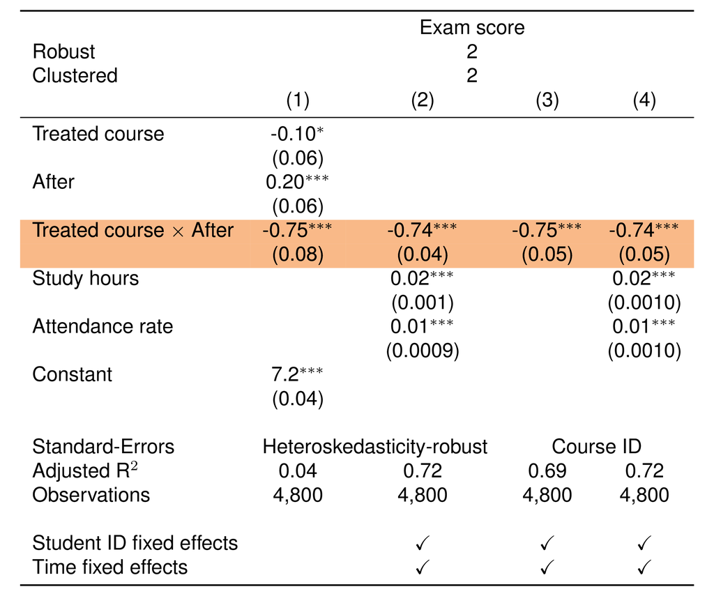

#### What changes with clustering?

- Standard errors increase when clustering by course, reflecting the within-course correlation of outcomes
- No change in point estimates, but the statistical significance of the treatment effect may change (e.g., from significant to non-significant)

## Difference-in-Differences (DiD)

### Standard errors

#### Key takeaways on standard errors in DiD settings

- Always use robust standard errors (solves heteroskedasticity issues)
- Rule of thumb I: Cluster at the level of the treatment/``shock’’, e.g. treatment is on state-level (new law) $\Rightarrow$ cluster standard errors at state
- Be careful: Less than $\approx$ 30 clusters makes standard errors too small
- Rule of thumb II: Check robustness of different cluster methods $\Rightarrow$ report most conservative one

## Difference-in-Differences (DiD)

### Takeaways so far

- DiD leverages both *cross-sectional and time-series* variation to identify causal effects (ATT)
- The canonical DiD model can be extended with fixed effects to control for *time-invariant heterogeneity*
- The **parallel trends assumption** is crucial for valid DiD inference
- Proper **standard error adjustments** are essential for accurate inference in DiD settings
- Is that all? Not quite…

**Limitations**

Limitations arise in **rollout (staggered)** designs, where treatment timing varies across groups; TWFE can perform poorly in such settings…

## Difference-in-Differences (DiD)

### Staggered adoption — The problem

#### The canonical DiD assumes a clean 2×2 world

|  | Before | After |
| --- | --- | --- |
| Treated | ✓ | ✓ |
| Control | ✓ | ✓ |

**Staggered (rollout) DiD**

When units receive treatment at **different points in time**, we call this a **staggered adoption** or **rollout** design. This is extremely common in finance and economics research.

*DiLLMa analogy*: Imagine LLM tools became available in some courses in semester 1, others in semester 3, and others never — the 2×2 structure breaks down.

## Difference-in-Differences (DiD)

### Staggered adoption — Why TWFE can go wrong

The standard Two-Way Fixed Effects (TWFE) estimator implicitly uses **all available 2×2 comparisons**, including some you probably don’t want:

#### Goodman-Bacon decomposition

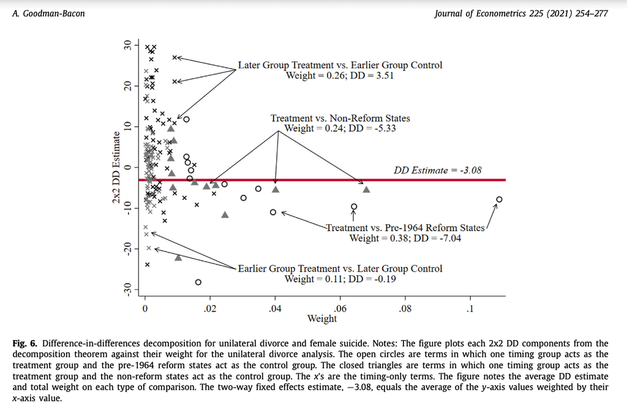

Goodman-Bacon (2021)

#### The “forbidden comparison” problem

- **Early-treated vs. never-treated** ✓ Clean comparison
- **Late-treated vs. never-treated** ✓ Clean comparison
- **Early-treated vs. late-treated** ⚠️ The already-treated group acts as a “control” — but they’ve already been treated!

## Difference-in-Differences (DiD)

### Staggered adoption — The negative weights problem info-pic

**The negative weights problem**

When treatment effects are **heterogeneous**, TWFE can assign **negative weights** to some group-time comparisons. This means TWFE can produce a negative estimate even when *every single unit* has a positive treatment effect. Goodman-Bacon (2021) decomposed TWFE into its component 2×2 DiDs and showed this explicitly.

#### Why does this happen?

- Suppose early-treated firms experience a large initial treatment effect that **fades over time**.
- TWFE will then use the later period, when the early-treated group’s effect has faded, as a “control” for the late-treated group.
- TWFE interprets the fading as a negative effect — even though the treatment was always positive.

The problem is not staggered adoption *per se* — it is staggered adoption **combined with treatment effect heterogeneity**.

## Difference-in-Differences (DiD)

### Staggered adoption — Recent solutions (high-level)

New approaches share a common idea: **only compare treated units to clean controls**

| Approach | Key idea | Reference |
| --- | --- | --- |
| **Callaway & Sant’Anna** | Estimate separate ATTs for each (group, time) cell, then aggregate | Callaway and Sant’Anna (2021) |
| **Sun & Abraham** | Interaction-weighted estimator; heterogeneity-robust | Sun and Abraham (2021) |
| **Borusyak, Jaravel & Spiess** | Imputation-based; efficient | Borusyak et al. (2024) |
| **Stacked DiD** | Manually construct clean 2×2 datasets and stack them | Cengiz et al. (2019) and Gormley and Matsa (2011) |

## Difference-in-Differences (DiD)

### Staggered adoption — Practical guidance

#### Rule of thumb

- If your setting is a **clean 2×2** (one treatment date, one treated group): standard TWFE is fine
- If your setting has **staggered rollout**: check for and report the Goodman-Bacon decomposition to understand how much your estimate is driven by “forbidden” comparisons
- If heterogeneous effects are plausible (they usually are): use Callaway-Sant’Anna or Sun-Abraham as robustness

For an accessible survey of the new methods, see Baker et al. (2022) — a practitioner-friendly overview.

## Difference-in-Differences (DiD)

### Beyond your MSc replication

#### New approaches

##### How to learn about the new approaches?

- See e.g. [Asjad Naqvi’s](https://asjadnaqvi.github.io/DiD/) Github repository that provides code and resources for implementing the new DiD methods or [Youtube lectures by the original authors](https://www.youtube.com/playlist?list=PLVObvb_htcuBt8mV9yNagt7hK9FL5KXeE)
- Check the papers by Callaway and Sant’Anna (2021), Sun and Abraham (2021), Borusyak et al. (2024), and Cengiz et al. (2019)
- Go beyond the literature in this course, e.g. Chaisemartin and D’Haultfœuille (2023)

##### Why should you care about the new approaches?

> A way to extend your MSc replication project is to apply some of the new DiD methods to your data and compare the results to the standard TWFE approach. This can provide insights into the robustness of your findings and demonstrate your ability to apply cutting-edge econometric techniques.

Thank You for Your Attention!

See You in the Next One!

## References

Abouk, Rahi, and Scott Adams. 2013. “Texting Bans and Fatal Accidents on Roadways: Do They Work? Or Do Drivers Just React to Announcements of Bans?” *American Economic Journal: Applied Economics* 5 (2): 179–99.

Baker, Andrew C, David F Larcker, and Charles CY Wang. 2022. “How Much Should We Trust Staggered Difference-in-Differences Estimates?” *Journal of Financial Economics* 144 (2): 370–95.

Borusyak, Kirill, Xavier Jaravel, and Jann Spiess. 2024. “Revisiting Event-Study Designs: Robust and Efficient Estimation.” *Review of Economic Studies* 91 (6): 3253–85.

Breuer, Matthias, and ED DeHaan. 2024. “Using and Interpreting Fixed Effects Models.” *Journal of Accounting Research* 62 (4): 1183–226.

Callaway, Brantly, and Pedro HC Sant’Anna. 2021. “Difference-in-Differences with Multiple Time Periods.” *Journal of Econometrics* 225 (2): 200–230.

Cameron, A Colin, and Douglas L Miller. 2015. “A Practitioner’s Guide to Cluster-Robust Inference.” *Journal of Human Resources* 50 (2): 317–72.

Cengiz, Doruk, Arindrajit Dube, Attila Lindner, and Ben Zipperer. 2019. “The Effect of Minimum Wages on Low-Wage Jobs.” *The Quarterly Journal of Economics* 134 (3): 1405–54.

Chaisemartin, Clément de, and Xavier D’Haultfœuille. 2023. “Credible Answers to Hard Questions: Differences-in-Differences for Natural Experiments.” *Available at SSRN 4487202*.

Cinelli, Carlos, Andrew Forney, and Judea Pearl. 2024. “A Crash Course in Good and Bad Controls.” *Sociological Methods & Research* 53 (3): 1071–104.

Goodman-Bacon, Andrew. 2021. “Difference-in-Differences with Variation in Treatment Timing.” *Journal of Econometrics* 225 (2): 254–77.

Gormley, Todd A, and David A Matsa. 2011. “Growing Out of Trouble? Corporate Responses to Liability Risk.” *The Review of Financial Studies* 24 (8): 2781–821.

Huntington-Klein, Nick. 2022. *The Effect: An Introduction to Research Design and Causality*. 2nd ed. Chapman; Hall/CRC.

Liu, Zack, and Adam Winegar. 2025. “Economic Magnitudes Within Reason.” *Journal of Corporate Finance* 83: 102707. https://doi.org/10.1016/j.jcorpfin.2024.102707.

Moulton, Brent R. 1990. “An Illustration of a Pitfall in Estimating the Effects of Aggregate Variables on Micro Units.” *The Review of Economics and Statistics*, 334–38.

Sun, Liyang, and Sarah Abraham. 2021. “Estimating Dynamic Treatment Effects in Event Studies with Heterogeneous Treatment Effects.” *Journal of Econometrics* 225 (2): 175–99.

Verbeek, Marno. 2021. *Panel Methods for Finance: A Guide to Panel Data Econometrics for Financial Applications*. De Gruyter.

# Appendix

## Difference-in-Differences (DiD)

### Parallel trends assumption

##### Unconditional means

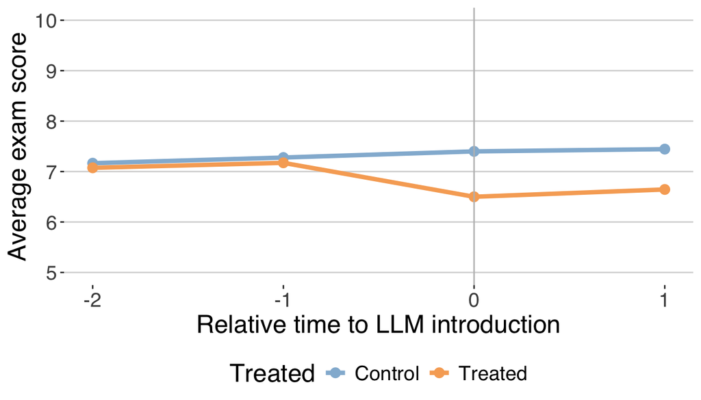

##### Event study approach

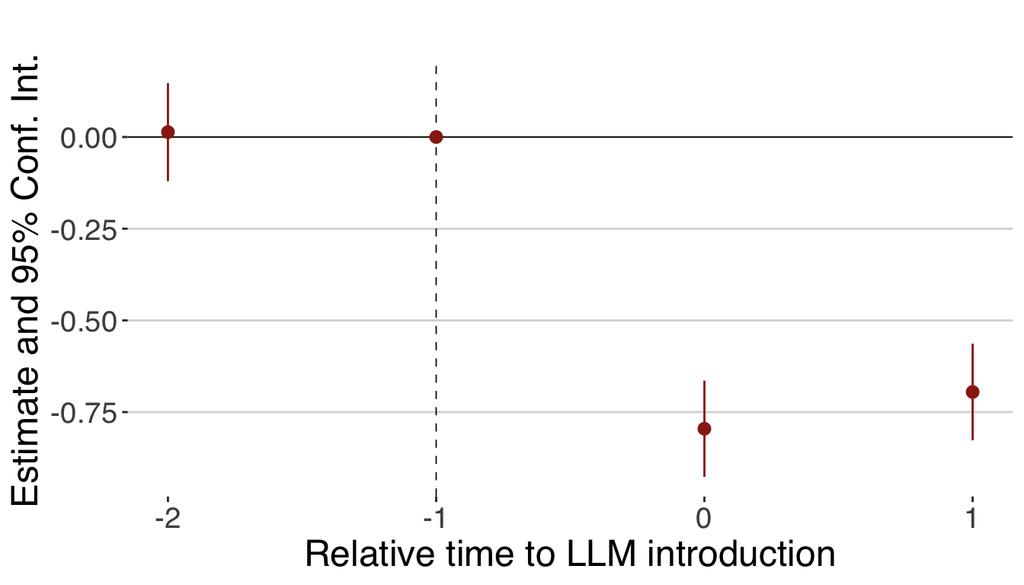

The parallel trends assumption states that, in the absence of treatment, the average change in the outcome variable would have been the same for both the treatment and control groups. Back

## Difference-in-Differences (DiD)

### Bacon decomposition - Infographic

[figure not shown]

Back

# Stata example - If time permits

## Stata example

### Texting bans and traffic accidents — Background

#### Cross-sectional variation

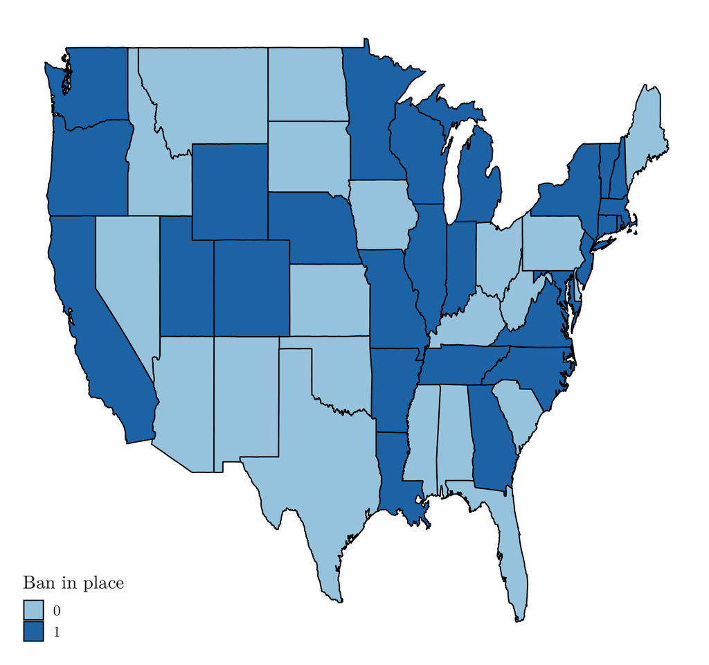

#### Temporal variation

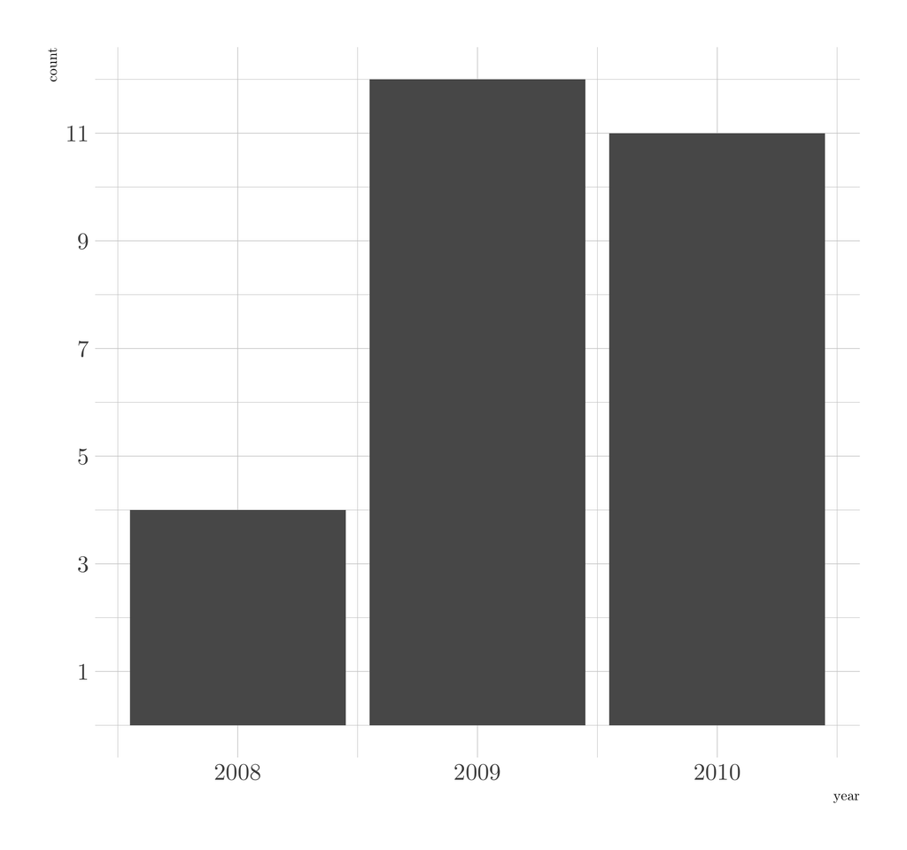

$$Y_{i,t} = \gamma_{State} + \theta_{Month} + \beta_3Ban_{i} \times Post_{t} + \epsilon_{i,t}$$

For all details, see and read Abouk and Adams (2013)

## Stata example

### Texting bans and traffic accidents — Main results

#### Main results

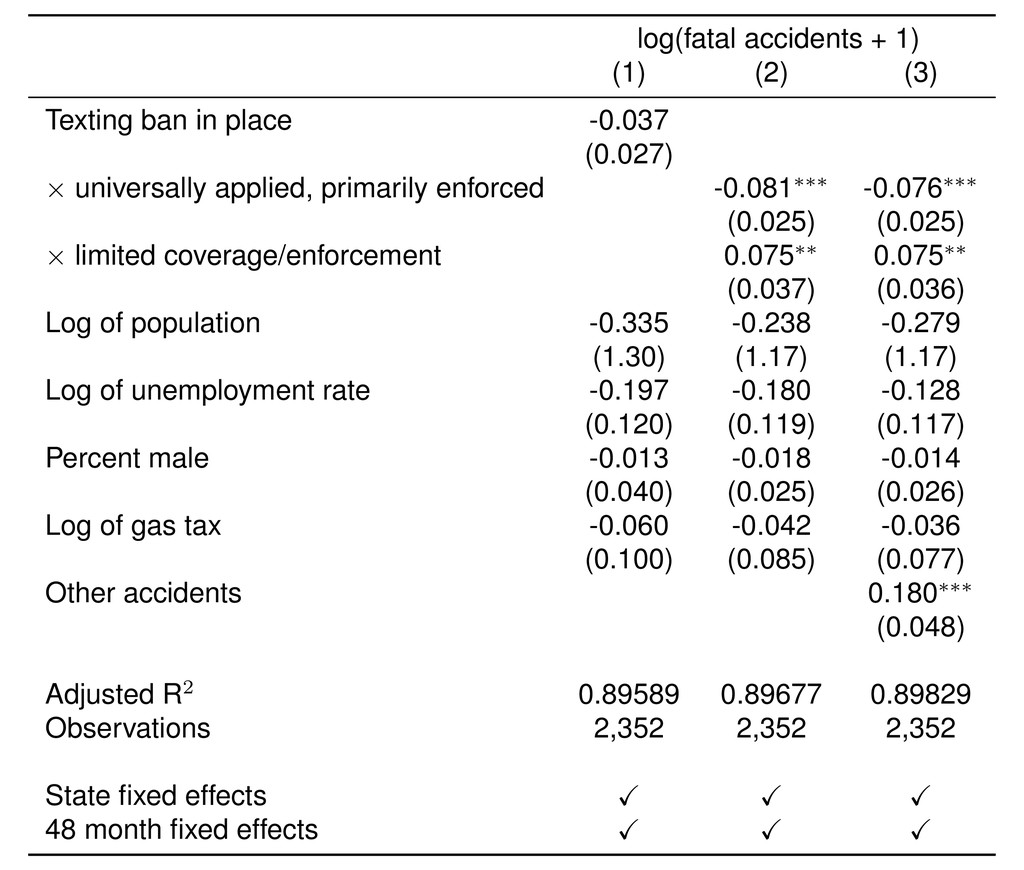

#### Interpretation

- 3.7% reduction of accidents in states after passing the ban compared to states without a ban in place
- Strong ban states: 8.1% reduction in accidents
- Weak ban states: 7.5% increase in accidents